# Predicting RSM Masters Enrollemnt - Machine Learning and Learning Algorithms (BM05BAM) Project

Plot the precision next:

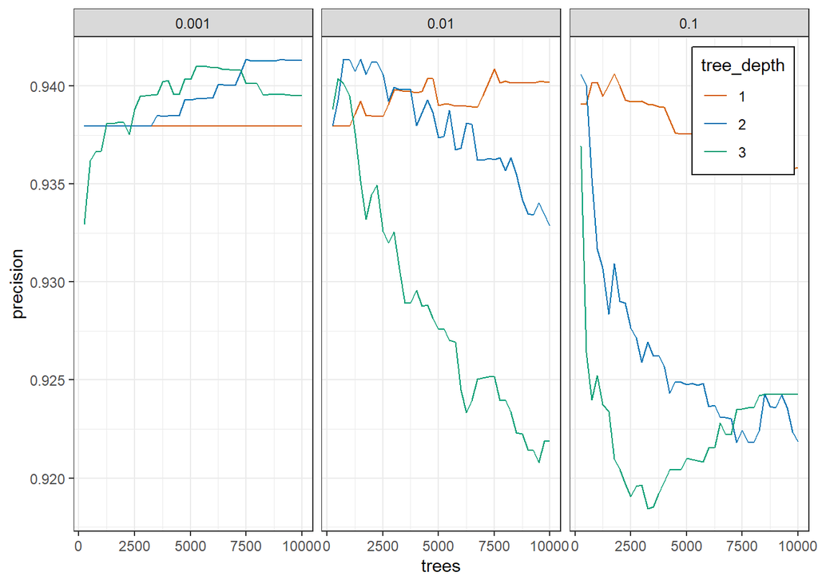

```r
xgb_tune_metrics |>
  filter(.metric == "precision") |>
  ggplot(aes(
    x = trees, y = mean,
    colour = factor(tree_depth)
  )) +
  geom_path() +
  labs(y = "precision") +
  scale_colour_manual(values = c("#D55E00", "#0072B2", "#009E73")) +
  facet_wrap(~learn_rate) +
  labs(colour = "tree_depth") +
  theme_bw() +
  theme(
    legend.position = c(.98, .98),
    legend.justification = c(1, 1),
    legend.background = element_rect(colour = "black")
  )
```

Whereas for precision, learn rate = 0.001 the performance is stable to the tree_depth used and trees. However, learn_rate = 0.01 & 0.1 is more sensitive to trees.

Plot accuracy and f meas:

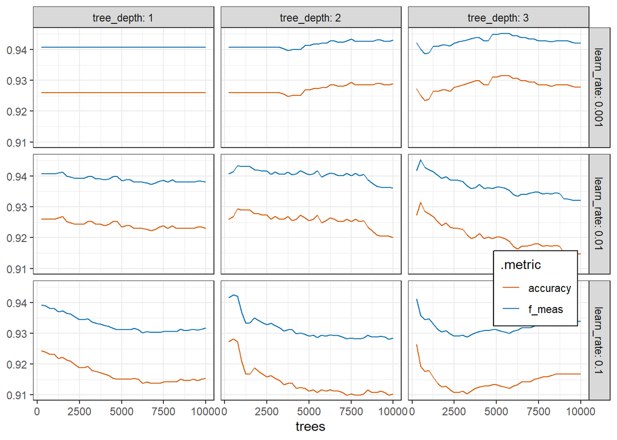

```r
xgb_tune_metrics |>
  filter(.metric %in% c("f_meas", "accuracy")) |>
  ggplot(aes(x = trees, y = mean, colour = .metric)) +
  geom_path() +
  facet_grid(learn_rate ~ tree_depth, labeller = label_both) +
  scale_colour_manual(values = c("#D55E00", "#0072B2")) +
  theme_bw() +
  labs(y = NULL) +
  theme(
    legend.position = c(.98, .2),
    legend.justification = c(1, 0),
    legend.background = element_rect(colour = "black")
  )
```

It can be seen that f_meas and accuracy is shown to agree on every single hyperparameter combination. So in conclusion, we want to focus on learn_rate == 0.001 & 0.01

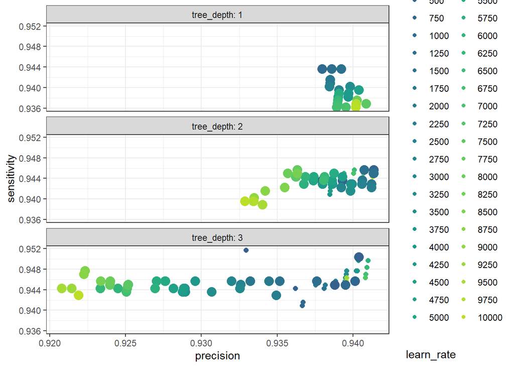

```r
#This plot also supports the idea of not using learn rate = 0.1. Furthermore, the lack of variability in tree_depth = 1 and learn rate =0.001
#is not very convincing.
xgb_tune_metrics |>
  filter(learn_rate < 0.1) |>
  select(trees:learn_rate, .metric, mean) |>
  pivot_wider(
    id_cols = trees:learn_rate,
    names_from = .metric,
    values_from = mean
  ) |>
  ggplot() +
  aes(
    x = precision, y = sensitivity,
    colour = factor(trees, ordered = TRUE),
    size = learn_rate
  ) +
  geom_point() +
  facet_wrap(~tree_depth, ncol = 1, labeller = label_both) +
  scale_size_continuous(range = c(2, 4), breaks = 10^c(-3, -2)) +
  scale_colour_viridis_d(begin = .3, end = .9, option = "D") +
  theme_bw() +
  labs(colour = "trees")
```

It can be seen that for learn_rate 0.01 (bigger dots) that a tree_depth of 3 and 2 shows great varition in performance. Whereas for tree_depth 1 we can see that number of trees somewhat agree with one another. Lastly, it is hard to see for learn rate 0.001 (so we are going to keep these observations).

Therefore, we will choose between (learn_rate == 0.01 & tree_depth 1) or (learn_rate == 0.001)

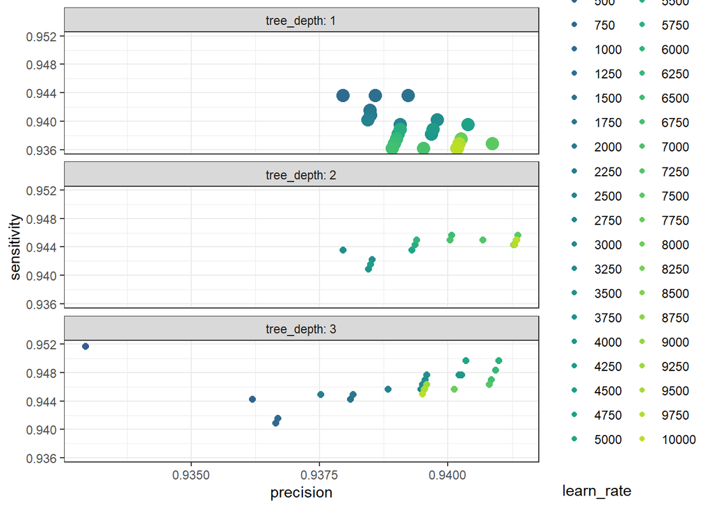

```r
xgb_tune_metrics |>
  filter((learn_rate == 0.01 & tree_depth == 1) |(learn_rate == 0.001))|>
  select(trees:learn_rate, .metric, mean) |>
  pivot_wider(
    id_cols = trees:learn_rate,
    names_from = .metric,
    values_from = mean
  ) |>
  ggplot() +
  aes(
    x = precision, y = sensitivity,
    colour = factor(trees, ordered = TRUE),
    size = learn_rate
  ) +
  geom_point() +
  facet_wrap(~tree_depth, ncol = 1, labeller = label_both) +
  scale_size_continuous(range = c(2, 4), breaks = 10^c(-3, -2)) +
  scale_colour_viridis_d(begin = .3, end = .9, option = "D") +
  theme_bw() +
  labs(colour = "trees")
```

We can see that for tree_depth == 3 & learn_rate == 0.001, it is still sensitive to number of trees, so we will drop these observations.

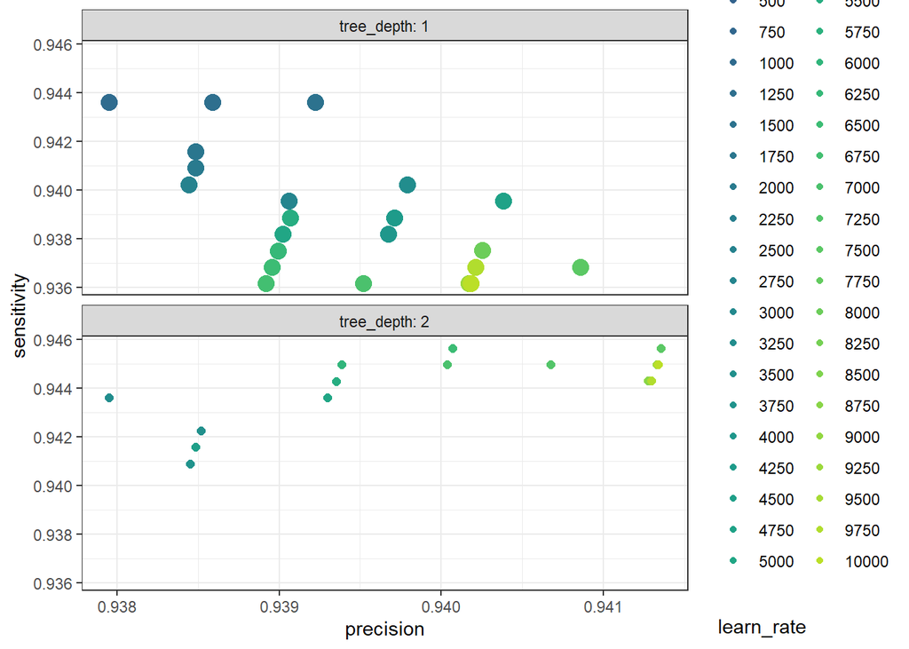

```r
xgb_tune_metrics |>
  filter((learn_rate == 0.01 & tree_depth == 1) |(learn_rate == 0.001 & tree_depth < 3))|>
  select(trees:learn_rate, .metric, mean) |>
  pivot_wider(
    id_cols = trees:learn_rate,
    names_from = .metric,
    values_from = mean
  ) |>
  ggplot() +
  aes(
    x = precision, y = sensitivity,
    colour = factor(trees, ordered = TRUE),
    size = learn_rate
  ) +
  geom_point() +
  facet_wrap(~tree_depth, ncol = 1, labeller = label_both) +
  scale_size_continuous(range = c(2, 4), breaks = 10^c(-3, -2)) +
  scale_colour_viridis_d(begin = .3, end = .9, option = "D") +
  theme_bw() +
  labs(colour = "trees")
```

We can see that within the clusters left, the performance does not differ by a significant margin. However, with boosting there is always a risk of overfitting if you have too much trees. Therefore, we will focus on observations of tree_depth == 1, learn_rate == 0.01 with a lower tree value.

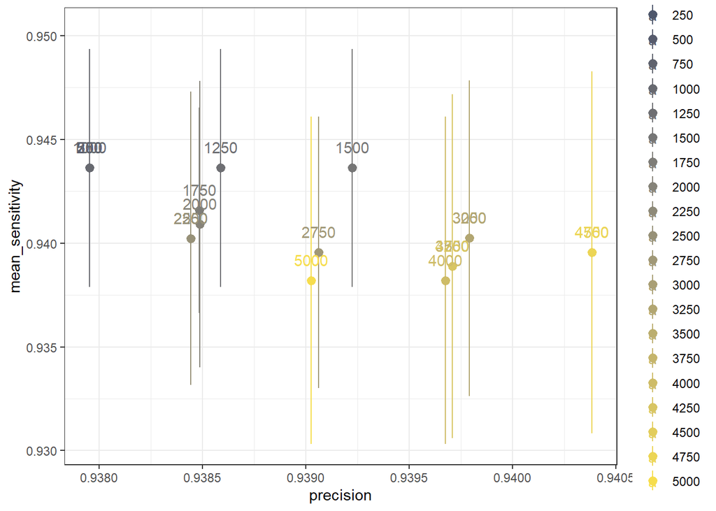

```r
xgb_tune_metrics |>
  filter(learn_rate == 0.01 & tree_depth == 1 & trees <= 5000) |>
  select(trees:learn_rate, .metric, mean, std_err) |>
  filter(.metric %in% c("sensitivity", "precision")) |>
  mutate(low = mean - std_err, high = mean + std_err) |>
  select(-std_err) |>
  pivot_wider(
    id_cols = trees:learn_rate,
    names_from = .metric,
    values_from = c(mean, low, high)
  ) |>
  select(trees, precision = mean_precision, ends_with("sensitivity")) |>
  ggplot() +
  aes(
    x = precision,
    y = mean_sensitivity, ymin = low_sensitivity, ymax = high_sensitivity,
    colour = factor(trees, ordered = TRUE)
  ) +
  geom_pointrange() +
  geom_text(aes(label = trees), position = position_nudge(y = .001)) +
  scale_colour_viridis_d(begin = .3, end = .95, option = "E") +
  theme_bw() +
  labs(colour = "trees")
```

From this plot we see the tree value that has a good balance of both sensitivity and precision is 1500 So, we choose a model with trees = 1500, tree_depth = 1, and learn_rate = 0.01.

```r
xgb_tune_metrics |>
  filter(trees == 1500 & tree_depth == 1 & learn_rate == 0.01)
```

| trees | tree_depth | learn_rate | .metric | .estimator | mean | n | std_err | .config |
| --- | --- | --- | --- | --- | --- | --- | --- | --- |
| 1500 | 1 | 0.01 | accuracy | binary | 0.9268783 | 5 | 0.006333080 | Preprocessor1_Model126 |
| 1500 | 1 | 0.01 | f_meas | binary | 0.9413788 | 5 | 0.005041718 | Preprocessor1_Model126 |
| 1500 | 1 | 0.01 | precision | binary | 0.9392234 | 5 | 0.005957154 | Preprocessor1_Model126 |
| 1500 | 1 | 0.01 | roc_auc | binary | 0.9618944 | 5 | 0.002744846 | Preprocessor1_Model126 |
| 1500 | 1 | 0.01 | sensitivity | binary | 0.9436204 | 5 | 0.005729094 | Preprocessor1_Model126 |

```r
xgb_tune_metrics |>
  filter(tree_depth == 1 & learn_rate == 0.01 & .metric == 'f_meas') |>
  arrange(desc(mean))
```

| trees | tree_depth | learn_rate | .metric | .estimator | mean | n | std_err | .config |
| --- | --- | --- | --- | --- | --- | --- | --- | --- |
| 1500 | 1 | 0.01 | f_meas | binary | 0.9413788 | 5 | 0.005041718 | Preprocessor1_Model126 |
| 1250 | 1 | 0.01 | f_meas | binary | 0.9410600 | 5 | 0.005092687 | Preprocessor1_Model125 |
| 250 | 1 | 0.01 | f_meas | binary | 0.9407375 | 5 | 0.004859796 | Preprocessor1_Model121 |
| 500 | 1 | 0.01 | f_meas | binary | 0.9407375 | 5 | 0.004859796 | Preprocessor1_Model122 |
| 750 | 1 | 0.01 | f_meas | binary | 0.9407375 | 5 | 0.004859796 | Preprocessor1_Model123 |
| 1000 | 1 | 0.01 | f_meas | binary | 0.9407375 | 5 | 0.004859796 | Preprocessor1_Model124 |
| 1750 | 1 | 0.01 | f_meas | binary | 0.9399919 | 5 | 0.004571567 | Preprocessor1_Model127 |
| 3000 | 1 | 0.01 | f_meas | binary | 0.9398791 | 5 | 0.003950380 | Preprocessor1_Model132 |
| 3250 | 1 | 0.01 | f_meas | binary | 0.9398791 | 5 | 0.003950380 | Preprocessor1_Model133 |
| 4500 | 1 | 0.01 | f_meas | binary | 0.9398240 | 5 | 0.004882217 | Preprocessor1_Model138 |

[output cut: 30 more lines]

```r
xgb_tune_metrics |>
  filter(tree_depth == 1 & learn_rate == 0.01 & .metric == 'f_meas' & trees <= 1500) |>
  arrange(desc(mean))
```

| trees | tree_depth | learn_rate | .metric | .estimator | mean | n | std_err | .config |
| --- | --- | --- | --- | --- | --- | --- | --- | --- |
| 1500 | 1 | 0.01 | f_meas | binary | 0.9413788 | 5 | 0.005041718 | Preprocessor1_Model126 |
| 1250 | 1 | 0.01 | f_meas | binary | 0.9410600 | 5 | 0.005092687 | Preprocessor1_Model125 |
| 250 | 1 | 0.01 | f_meas | binary | 0.9407375 | 5 | 0.004859796 | Preprocessor1_Model121 |
| 500 | 1 | 0.01 | f_meas | binary | 0.9407375 | 5 | 0.004859796 | Preprocessor1_Model122 |
| 750 | 1 | 0.01 | f_meas | binary | 0.9407375 | 5 | 0.004859796 | Preprocessor1_Model123 |
| 1000 | 1 | 0.01 | f_meas | binary | 0.9407375 | 5 | 0.004859796 | Preprocessor1_Model124 |

If we do one standard error below this model and try to find a simpler model with less number of trees, we arrive at a trees value equal to 250 (simplest possible model in this grid).

Now, we can finalise the workflow.

```r
selected_xgb <-
  xgb_tune_metrics|>
  filter(tree_depth == 1, learn_rate == 0.01, trees == 250) |>
  distinct(trees, tree_depth, learn_rate)

xgb_final_wf <-
  finalize_workflow(xgb_tune_wf, selected_xgb)
xgb_final_wf
```

```
## ══ Workflow ════════════════════════════════════════════════════════════════════
## Preprocessor: Recipe
## Model: boost_tree()
##
## ── Preprocessor ────────────────────────────────────────────────────────────────
## 2 Recipe Steps
##
## • step_dummy()
## • step_upsample()
##
## ── Model ───────────────────────────────────────────────────────────────────────
## Boosted Tree Model Specification (classification)
##
## Main Arguments:
##   trees = 250
##   tree_depth = 1
##   learn_rate = 0.01
##   stop_iter = 500
##
## Computational engine: xgboost
```

```r
xgb_final_fit <-
  xgb_final_wf |>
  last_fit(
    analysis_assesment_split, metrics = class_metrics
  )
```

```
## → A | warning: `early_stop` was reduced to 249.
```

```
##
There were issues with some computations   A: x1

There were issues with some computations   A: x1
```

```r
xgb_test_metrics <-
  xgb_final_fit |>
  collect_metrics() |>
  select(.metric,.estimate) |>
  mutate(model = 'xgb')
xgb_test_metrics
```

| .metric | .estimate | model |
| --- | --- | --- |
| f_meas | 0.9682620 | xgb |
| sensitivity | 0.9449361 | xgb |
| precision | 0.9927686 | xgb |
| accuracy | 0.9614914 | xgb |
| roc_auc | 0.9776561 | xgb |

```r
rf_metrics_final <-
  rf_metrics |>
  select(.metric,.estimate) |>
  mutate(model = 'rf')
```

Combine the results of all 6 models:

```r
xgb_knn_regularization_rf_test_metrics <-
  bind_rows(knn_metrics, lasso_test_metrics, ridge_test_metrics, elastic_net_test_metrics, xgb_test_metrics,rf_metrics_final) |>
  pivot_wider(names_from = .metric, values_from = .estimate) |>
  arrange(desc(f_meas))
xgb_knn_regularization_rf_test_metrics
```

| model | f_meas | sensitivity | precision | accuracy | roc_auc |
| --- | --- | --- | --- | --- | --- |
| lasso | 0.9682620 | 0.9449361 | 0.9927686 | 0.9614914 | 0.9758921 |
| xgb | 0.9682620 | 0.9449361 | 0.9927686 | 0.9614914 | 0.9776561 |
| rf | 0.9651394 | 0.9528024 | 0.9778002 | 0.9572127 | 0.9830983 |
| elastic net | 0.9638917 | 0.9449361 | 0.9836233 | 0.9559902 | 0.9764870 |
| ridge | 0.9572650 | 0.9360865 | 0.9794239 | 0.9480440 | 0.9777975 |
| knn | 0.8688306 | 0.9606686 | 0.7930195 | 0.8196822 | 0.9359594 |

We will choose lasso because it performs the best. While xgb has the upper edge compared to lasso on roc_auc, because of lasso’s simplicity, we will choose lasso. Quoting Occam’s Razor, we will always choose a simpler model over a more complicated model if the performance is the same.

Additionally, Lasso has a few benefits. They include:

- Explainability: Lasso is a model that is built on top of a Simple Linear Regression, so it is much more simpler to explain how the model creates its predictions. People at the admissions office will be able to rationalize how the enrollment process is for students This opens up the possibility of the admissions office to alter their application process to better fit their intended outcome.
- Lower of risk of overfitting compared to more complicated models.
- Very simple and Cost efficient!

# Predictions

Next, we will call last_fit() and pass in the final/prediction split object. We include roc_auc as a metric in order for last_fit() to automatically generate soft predictions.

```r
final_metric <- metric_set(f_meas, roc_auc)
final_model <-
  lasso_wf_tuned |>
  last_fit(final_training_prediction_split,
    metrics = final_metric
  ) |>
  suppressWarnings()
```

[output not shown]

```
##
There were issues with some computations   A: x1

There were issues with some computations   A: x1
```

After fitting the model, we generate the prediction for each program. We have decided to use a threshold of 0.45. The reason for this include:

- We want to capture less false negatives
- Underprediction is dangerous because we will not be able to allocate the programs to appropriately sized rooms.
- However, we avoided going any lower due to the fact that we already did upsampling because this made our model more sensitive to the negative class in general.

```r
final_model_df <-
  final_model |>
  augment() |>
  group_by(Program) |>
  summarise(
    Predicted_N = sum(.pred_Enrolled >= 0.45),
    Predicted_Prob = mean(.pred_Enrolled)
  )
final_model_df
```

| Program | Predicted_N | Predicted_Prob |
| --- | --- | --- |
| MScBA-AFM | 47 | 0.4810117 |
| MScBA-BAM | 146 | 0.5835712 |
| MScBA-MIM | 54 | 0.4165169 |
| MScBIM | 82 | 0.6188868 |
| MScFI | 404 | 0.6253893 |
| MScGBS | 77 | 0.5573160 |
| MScMI | 28 | 0.5407118 |
| MScMM | 112 | 0.6055526 |
| MScSCM | 48 | 0.5898280 |
| MScSE | 34 | 0.6076915 |

[output cut: 1 more lines]

# Implementing New uncensored data

```r
load('offers_uncensored.RData')
```

The following steps will be similar to what we have done at the start of the file.

```r
full_uncensored_data <-
  offers |>
  # change responses received after March 14 to "Unknown"
  censor_post_prediction_responses() |>
  # drop offers sent out after March 14
  drop_post_prediction_offers()
```

## Feature Engineering

Same steps as previously

```r
full_uncensored_data$Respond_by_0315 <- ifelse(is.na(full_uncensored_data$ResponseDate), 0, 1)
full_uncensored_data$Difference_App_Off <- full_uncensored_data$OfferDate - full_uncensored_data$AppDate
full_uncensored_data$March15_AcademicYear <- as.Date(paste(full_uncensored_data$AppYear, "-03-15", sep=""))
full_uncensored_data$Difference_to_March15 <- full_uncensored_data$March15_AcademicYear - full_uncensored_data$AppDate
full_uncensored_data$Difference_App_Off <- as.numeric(as.character(full_uncensored_data$Difference_App_Off))
full_uncensored_data$Difference_to_March15 <- as.numeric(as.character(full_uncensored_data$Difference_to_March15))
full_uncensored_data$AppYearFactor <- as.factor(full_uncensored_data$AppYear)
```

## Data Splitting

```r
set.seed(123)
analysis_assesment_split_uncensored <-
    full_uncensored_data |>
    filter(AppYear > 2020) |>
    make_appyear_split(test_year = 2023)
```

## Analysis

```r
train <- training(analysis_assesment_split_uncensored) # 2021 + 2022 data
test <- testing(analysis_assesment_split_uncensored) # 2023 data
```

## Fit The best model

```r
lasso_last_fit_final <-
  lasso_wf_tuned |>
  last_fit(analysis_assesment_split_uncensored, metrics = class_metrics)

lasso_test_metrics_final <-
  lasso_last_fit_final |>
  collect_metrics()

lasso_test_metrics_final
```

| .metric | .estimator | .estimate | .config |
| --- | --- | --- | --- |
| f_meas | binary | 0.9846384 | Preprocessor1_Model1 |
| sensitivity | binary | 0.9704579 | Preprocessor1_Model1 |
| precision | binary | 0.9992395 | Preprocessor1_Model1 |
| accuracy | binary | 0.9801837 | Preprocessor1_Model1 |
| roc_auc | binary | 0.9893772 | Preprocessor1_Model1 |

## Predictions

```r
pred_table <-
  final_model_df <-
  lasso_last_fit_final |>
  augment() |>
  group_by(Program) |>
  summarise(
    Predicted_N = sum(.pred_Enrolled >= 0.45)
  )

act <-
  lasso_last_fit_final |>
  augment() |>
  group_by(Program) |>
  count(Status) |>
  filter(Status == 'Enrolled') |>
  select(!Status) |>
  rename(actual_n = n)


act_pred_comp_prog <- merge(pred_table,act, by = 'Program')
act_pred_comp_prog
```

| Program | Predicted_N | actual_n |
| --- | --- | --- |
| MScBA-AFM | 47 | 49 |
| MScBA-BAM | 146 | 146 |
| MScBA-MIM | 54 | 54 |
| MScBIM | 82 | 86 |
| MScFI | 404 | 411 |
| MScGBS | 77 | 85 |
| MScMI | 28 | 30 |
| MScMM | 112 | 116 |
| MScSCM | 48 | 50 |
| MScSE | 34 | 36 |

[output cut: 1 more lines]

Obtain the confusion matrix with our specified threshold

```r
#Apply our threshold
lasso_last_fit_final_new_thres <-
  lasso_last_fit_final |>
  collect_predictions() |>
  mutate(.pred_class = as.factor(ifelse(.pred_Enrolled >= 0.45, "Enrolled", "Not enrolled")))

lasso_last_fit_final_new_thres |>
  conf_mat(Status, .pred_class)
```

```
##               Truth
## Prediction     Enrolled Not enrolled
##   Enrolled         1314            1
##   Not enrolled       40          714
```

We can see that our model works really well in predicting negative cases. We only had one instance of False Positives, whereas we have 40 instances of False Negatives.

We get the estimated coefficients oflasso.

```r
lasso_last_fit_final |>
  extract_fit_parsnip() |>
  tidy() |>
  arrange(desc(abs(estimate)))
```

| term | estimate | penalty |
| --- | --- | --- |
| Respond_by_0315 | -1.828345e+00 | 0.05722368 |
| Response_Deferred | 3.205211e-01 | 0.05722368 |
| (Intercept) | -2.947574e-01 | 0.05722368 |
| Response_Declined | 2.599864e-01 | 0.05722368 |
| Demo2_Y | -6.255607e-05 | 0.05722368 |
| Response_Unknown | 4.484189e-14 | 0.05722368 |
| Demo3_WA | -1.592135e-16 | 0.05722368 |
| App4 | 0.000000e+00 | 0.05722368 |
| Difference_App_Off | 0.000000e+00 | 0.05722368 |
| Difference_to_March15 | 0.000000e+00 | 0.05722368 |

[output cut: 148 more lines]

We see that out of the possible 158 variables, only 6 was selected by the lasso model. Namely, Response is shown to have a high predictive power because all four categories are selected. Additionally, the difference between Demo2_Y and the reference group Demo2_W is also important. Lastly, the dummy variable that we generated `Respond_by_0315` is also important.

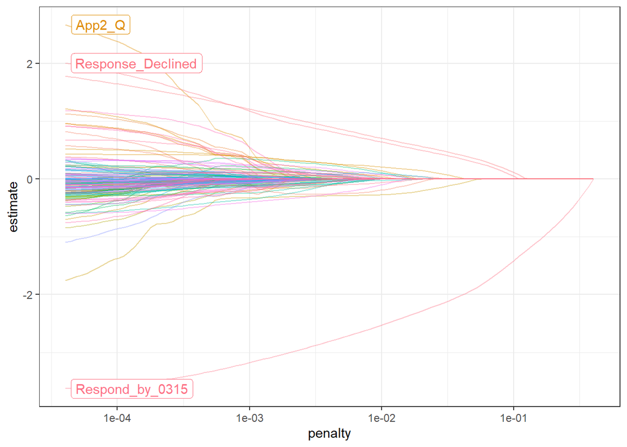

```r
lasso_last_fit_final |>
  extract_fit_parsnip() |>
  autoplot() +
  theme_bw()
```

We can also see that ‘Respond_by_0315’ is the feature that was shrunk last given an increasing penalty in the lasso model.

## Check where the model miss-classified

```r
lasso_last_fit_final |>
  augment() |>
  filter(Status != .pred_class)
```

| Status | AppYear | Program | AppDate | OfferDate | ResponseDate | Response | Demo1 | Demo2 | Demo3 | Edu1 | Edu2 | Edu3 | App1 | App2 | App3 | App4 | HowFirstHeard | Respond_by_0315 | Difference_App_Off | March15_AcademicYear | Difference_to_March15 | AppYearFactor | .pred_Enrolled | .pred_Not enrolled | .pred_class |
| --- | --- | --- | --- | --- | --- | --- | --- | --- | --- | --- | --- | --- | --- | --- | --- | --- | --- | --- | --- | --- | --- | --- | --- | --- | --- |
| Enrolled | 2023 | MScBA-AFM | 2023-01-28 | 2023-03-07 |  | Unknown | V | W | ZV | DDR | LR | B | T | D | B | 0 | Advice from others | 0 | 38 | 2023-03-15 | 46 | 2023 | 0.1159800 | 0.8840200 | Not enrolled |
| Enrolled | 2023 | MScBA-AFM | 2023-01-30 | 2023-03-13 |  | Unknown | V | W | MR | HRU | FK | B | S | C | B | 0 | Current student at RSM | 0 | 42 | 2023-03-15 | 44 | 2023 | 0.1159800 | 0.8840200 | Not enrolled |
| Not enrolled | 2023 | MScBA-MIM | 2022-11-01 | 2022-12-19 | 2022-12-29 | Accepted | U | X | NG | Other | XU | B | S | R | B | 0 | Family, friend or relative | 1 | 48 | 2023-03-15 | 134 | 2023 | 0.8534618 | 0.1465382 | Enrolled |
| Enrolled | 2023 | MScBA-MIM | 2023-01-26 | 2023-03-08 |  | Unknown | V | X | TQ | Other | UF | B | T | A | B | 0 | Ranking | 0 | 41 | 2023-03-15 | 48 | 2023 | 0.1159800 | 0.8840200 | Not enrolled |
| Enrolled | 2023 | MScBIM | 2022-10-08 | 2022-10-27 |  | Unknown | V | Y | WA | CRS | FK | B | T | M | B | 0 | Family, friend or relative | 0 | 19 | 2023-03-15 | 158 | 2023 | 0.1159929 | 0.8840071 | Not enrolled |
| Enrolled | 2023 | MScBIM | 2022-10-31 | 2022-11-11 |  | Unknown | V | Y | WA | SHJ | FK | B | T | M | B | 0 | Family, friend or relative | 0 | 11 | 2023-03-15 | 135 | 2023 | 0.1159929 | 0.8840071 | Not enrolled |
| Enrolled | 2023 | MScBIM | 2023-01-28 | 2023-02-17 |  | Unknown | V | W | NA | EQY | FK | B | S | C | A | 4 | Current student at RSM | 0 | 20 | 2023-03-15 | 46 | 2023 | 0.1159800 | 0.8840200 | Not enrolled |
| Enrolled | 2023 | MScBIM | 2023-01-30 | 2023-03-13 |  | Unknown | U | Y | WA | EQY | FK | B | S | C | A | 3 | Current student at RSM | 0 | 42 | 2023-03-15 | 44 | 2023 | 0.1159929 | 0.8840071 | Not enrolled |
| Enrolled | 2023 | MScFI | 2022-10-06 | 2022-10-11 |  | Unknown | V | Y | WA | EQY | FK | B | T | Q | A | 4 | RSM alumnus / RSM graduate | 0 | 5 | 2023-03-15 | 160 | 2023 | 0.1159929 | 0.8840071 | Not enrolled |
| Enrolled | 2023 | MScFI | 2022-10-27 | 2022-11-10 |  | Unknown | V | Y | WA | EQY | FK | B | T | Q | A | 4 | Current student at RSM | 0 | 14 | 2023-03-15 | 139 | 2023 | 0.1159929 | 0.8840071 | Not enrolled |

[output cut: 31 more lines]

We found 41 observations where our prediction was wrongly classified.

```r
enrollment_actual_program <- lasso_last_fit_final |>
  augment() |>
  filter(Status == 'Enrolled') |>
  group_by(Program) |>
  count(Program) |>
  arrange(desc(n)) |>
  rename(actual_enrollments = n)

enrollment_program <-
  lasso_last_fit_final |>
  augment() |>
  filter(Status != .pred_class) |>
  group_by(Program) |>
  count(Program) |>
  arrange(desc(n)) |>
  rename(missprediction = n)

enrollment_error <- merge(enrollment_program, enrollment_actual_program, by = "Program")

enrollment_error |>
  mutate(
    miss_prediction_share = missprediction/actual_enrollments
  )
```

| Program | missprediction | actual_enrollments | miss_prediction_share |
| --- | --- | --- | --- |
| MScBA-AFM | 2 | 49 | 0.04081633 |
| MScBA-MIM | 2 | 54 | 0.03703704 |
| MScBIM | 4 | 86 | 0.04651163 |
| MScFI | 7 | 411 | 0.01703163 |
| MScGBS | 8 | 85 | 0.09411765 |
| MScMI | 2 | 30 | 0.06666667 |
| MScMM | 4 | 116 | 0.03448276 |
| MScSCM | 2 | 50 | 0.04000000 |
| MScSE | 2 | 36 | 0.05555556 |
| MScSM | 8 | 291 | 0.02749141 |

The table above provide an overview on which programs did we make wrong classifications.

See where in predictor Demo2 did our model make wrong classification.

```r
lasso_last_fit_final |>
  augment() |>
  filter(Status != .pred_class) |>
  group_by(Demo2) |>
  count(Demo2) |>
  arrange(desc(n))
```

| Demo2 | n |
| --- | --- |
| Y | 29 |
| W | 9 |
| X | 3 |

We observe that out of the 41 observations, most of the misclassification on Demo2 occurs on variable Y.

See where in predictor Response did our model make wrong classification.

```r
lasso_last_fit_final |>
  augment() |>
  filter(Status != .pred_class) |>
  group_by(Response) |>
  count(Response) |>
  arrange(desc(n))
```

| Response | n |
| --- | --- |
| Unknown | 40 |
| Accepted | 1 |

We observe that out of the 41 observations, most of the misclassification on Response occurs on variable Unknown.

This can be further checked with the code below

```r
lasso_last_fit_final |>
  augment() |>
  filter(Status != .pred_class) |>
  group_by(Respond_by_0315) |>
  count(Respond_by_0315) |>
  arrange(desc(n))
```

| Respond_by_0315 | n |
| --- | --- |
| 0 | 40 |
| 1 | 1 |

ROC curve

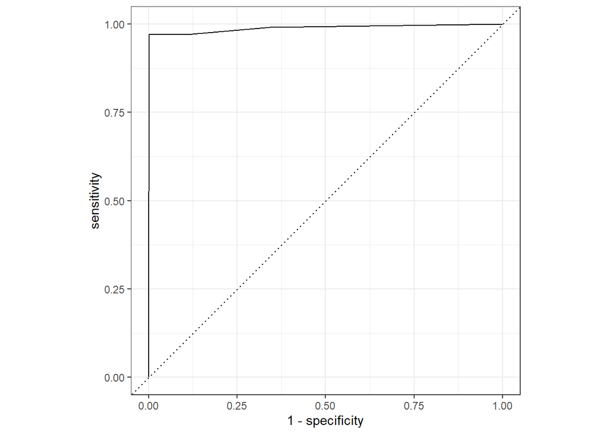

```r
lasso_last_fit_final |>
  collect_predictions() |>
  roc_curve(Status, .pred_Enrolled) |>
  autoplot()
```

We observe that the ROC curve indicate that our model performs similarly to a theoretical ‘Perfect Model’ because our curve hugs the top left hand corner.

Gain curve:

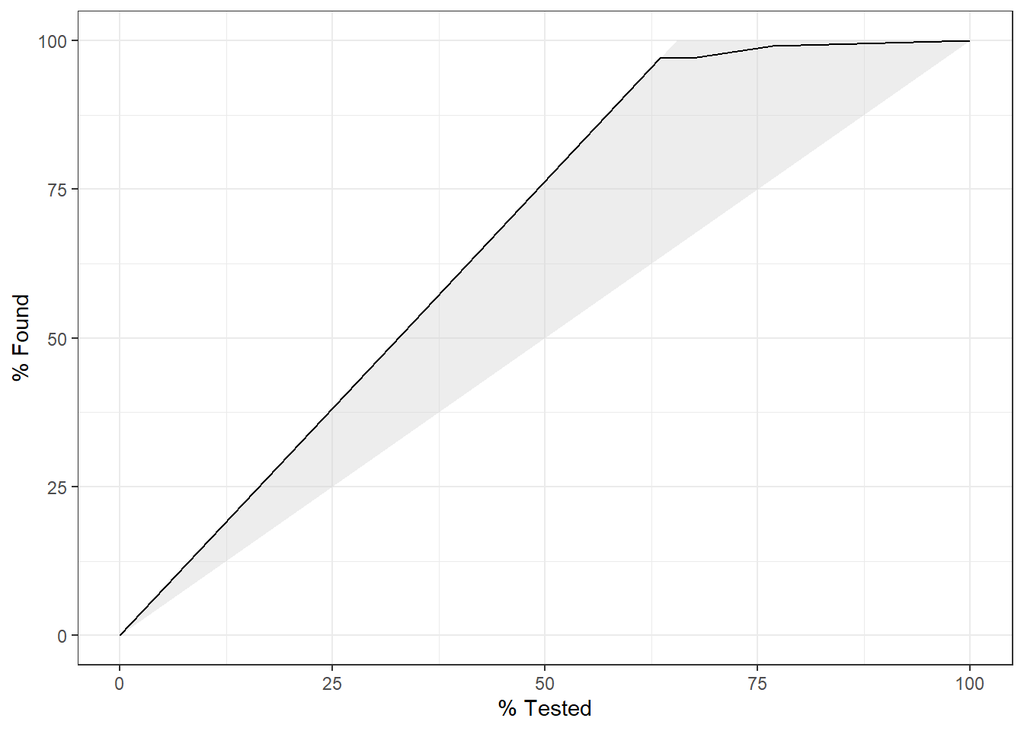

```r
lasso_last_fit_final |>
  collect_predictions() |>
  gain_curve(Status, .pred_Enrolled) |>
  autoplot()
```

We can see that the gain curve indicates that we also perform really well relative to the ‘Perfect Model’ Indicated by the shaded region.

End of Project

```
beepr::beep()
```